# Tarea-06

Author

Brandon Francisco Hernández Troncoso

```r
library(tidyverse)
library(patchwork)
```

# Teorema central del límite

**Ejercicio 1**: Consideremos la distribución gamma con parámetro de forma a = 5, tasa lambda = 0.1. Su media teórica es $5/0.1 = 50$, cuya densidad teórica es:

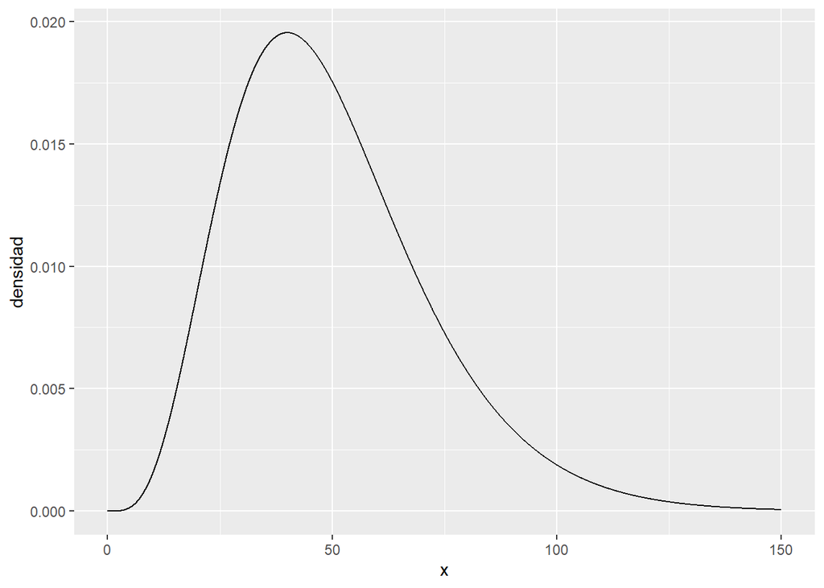

```r
x <- seq(0, 150, 0.01)
tibble(x = x) %>%
  mutate(densidad = dgamma(x, 5, 0.1)) %>%
  ggplot(aes(x = x, y = densidad)) + geom_line()
```

Tomamos una muestra:

```r
set.seed(232)
n <- 200
muestra <- tibble(sample = rgamma(n, 5, 0.1))
```

La distribución de los datos se ve como sigue:

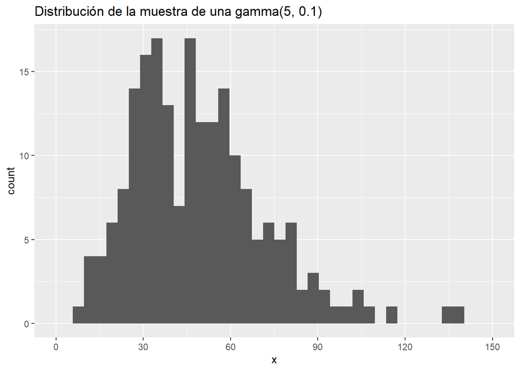

```r
ggplot(muestra, aes(x=sample)) +
  geom_histogram(bins=40) +
  labs(title="Distribución de la muestra de una gamma(5, 0.1)") +
  xlab("x") +
  scale_x_continuous(breaks = seq(0, 150, 30), limits = c(0, 150))
```

**¿Parece tener distribución normal?**

No parece tener una distribución normal. La distribución de la muestra representa la distribución empírica, por lo que con nuestra muestra de tamaño 200 estamos aproximando la distribución poblacional, que es la distribución Gamma.

Ahora consideramos la distribución de muestreo de la media de esta distribución, con tamaño de muestra fijo n

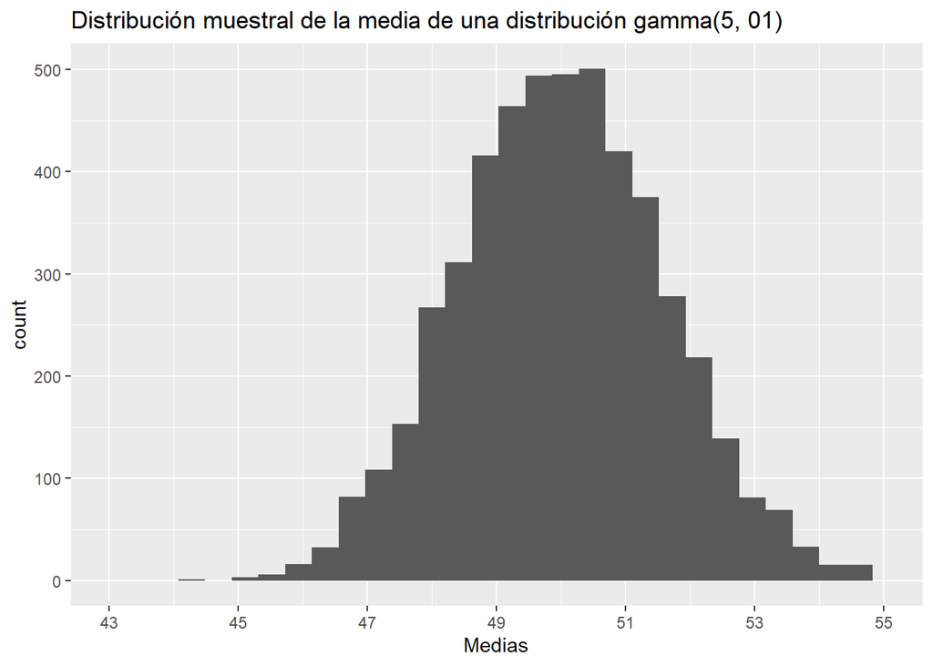

```r
medias <- map_dbl(1:5000,  ~ mean(rgamma(n, 5, 0.1)))
medias_gamma <- tibble(medias = medias)
hist_medias <- ggplot(medias_gamma, aes(x=medias)) +
                geom_histogram(bins=30) +
                labs(title="Distribución muestral de la media de una distribución gamma(5, 01)") +
                xlab("Medias") +
                scale_x_continuous(breaks = seq(43, 55, 2), limits = c(43, 55))
hist_medias
```

**¿El histograma anterior se ve normal?**

Sí, pareciera tener la forma de una distribución normal centrada en $50$.

**Ejercicio 2 (Mezcla de distribuciones)**: Este ejemplo es más complicado. Imaginemos que nuestro modelo teórico es una mezcla de dos poblaciones, una gamma y una normal

```r
muestrear_pob <- function(n){
  u <- runif(n) # número aleatorio
  map_dbl(u, ~ ifelse(.x < 1/2, rgamma(1, 5, 0.1), rnorm(1, 100, 5)))
}
```

El modelo teórico se puede graficar, pero también podemos obetener una aproximación buena haciendo una cantidad grande de simulaciones

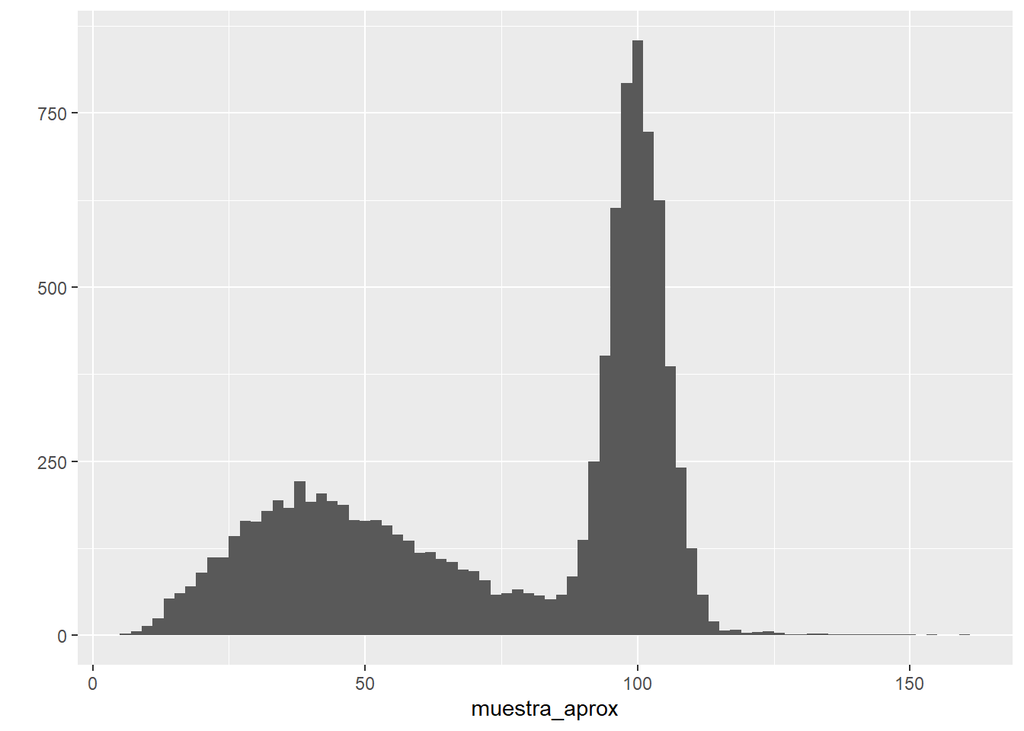

```r
muestra_aprox <- muestrear_pob(10000)
qplot(muestra_aprox, binwidth= 2)
```

Ahora consideramos estimar la media de esta distribución con un muestra de tamaño 100

**¿Cómo se ve la distribución de muestreo de la media? Grafica un histograma y una gráfica cuantil-cuantil normal**

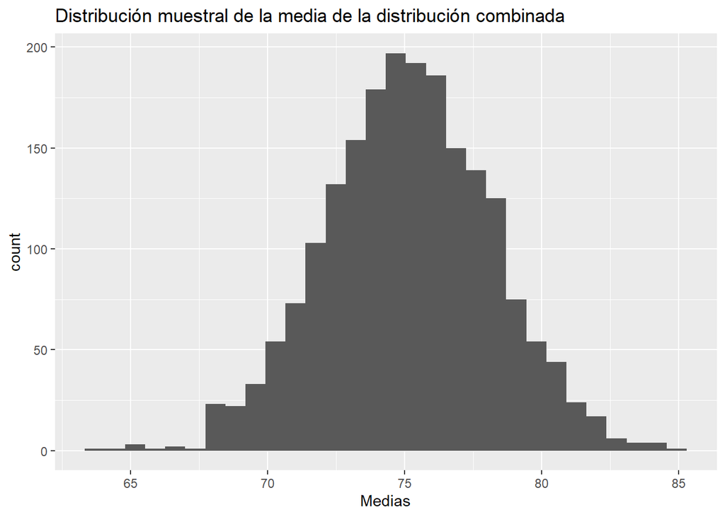

```r
medias <- map_dbl(1:2000,  ~ mean(sample(muestra_aprox, 100)))

medias_combinada <- tibble(medias = medias)
hist_medias_combinada <- ggplot(medias_combinada, aes(x=medias)) +
                geom_histogram(bins=30) +
                labs(title="Distribución muestral de la media de la distribución combinada") +
                xlab("Medias")

hist_medias_combinada
```

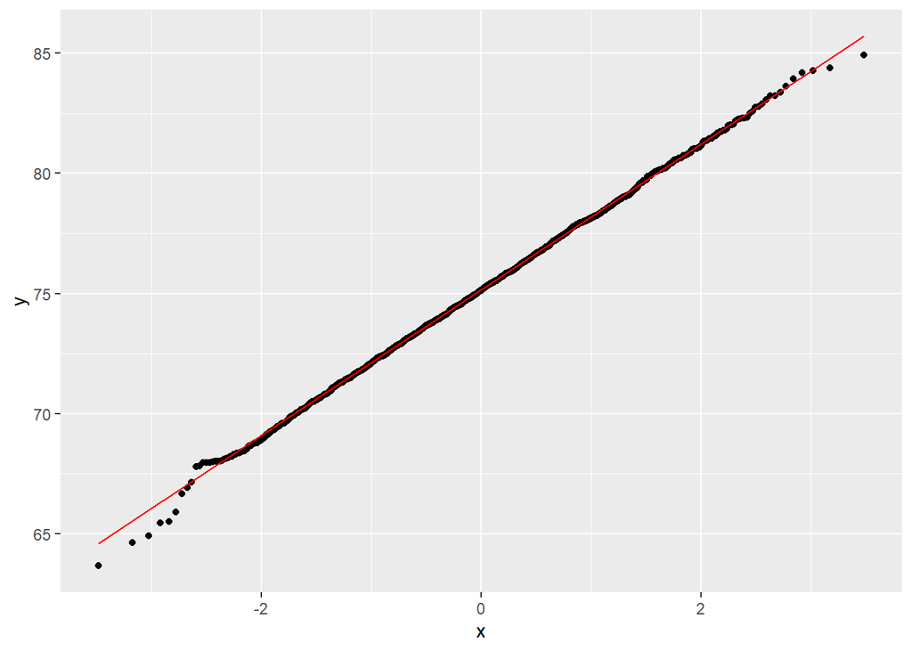

```r
quantile_norm <- ggplot(medias_combinada, aes(sample = medias)) +
            geom_qq(distribution = stats::qnorm) +
            geom_qq_line(colour = "red")
quantile_norm
```

La gráfica de la distribución muestral de la media parece tender a una distribución normal. También la gráfica cuantil-cuantil pareciera que los cuantiles de la distribución muestral son similares a los de una distribución normal estandarizada. Los puntos fuera de la recta qq parecen ser provocados por la variación muestral.

**Ejercicio 3 (ejemplo discreto):** Tomaremos muestras de unos y ceros

```r
set.seed(1212)
n_volados <- 200
muestra <- rbinom(n_volados, 1, prob = 0.7)
head(muestra)
```

```
[1] 1 1 0 1 1 1
```

La media es la proporción de unos en la muestra, o la proporción de “soles”:

```r
mean(muestra)
```

```
[1] 0.785
```

**¿Cuál es la distribución de muestreo para la proporción de soles en la muestra?**

```r
prop_soles <- map_dbl(1:10000,  ~ mean(sample(rbinom(n_volados, 1, prob = 0.7))))
prop_soles_tbl <- tibble(prop_soles = prop_soles)
```

Checa un histograma, ¿se ve normal? También ve una gráfica qq

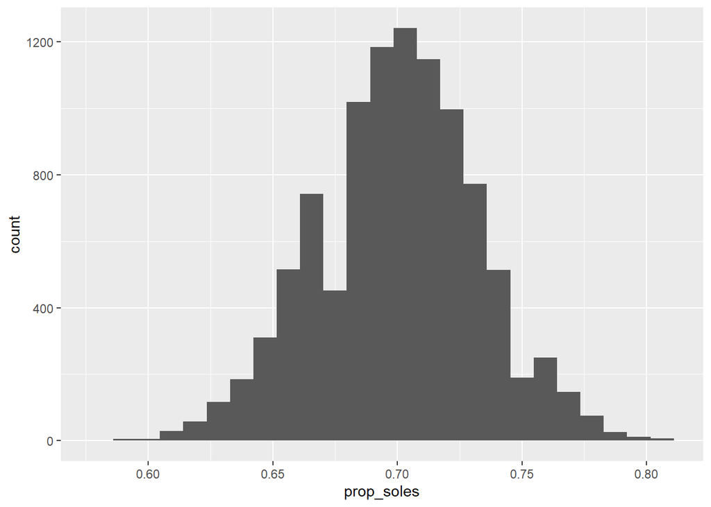

```r
ggplot(prop_soles_tbl, aes(x = prop_soles)) + geom_histogram(bins=25)
```

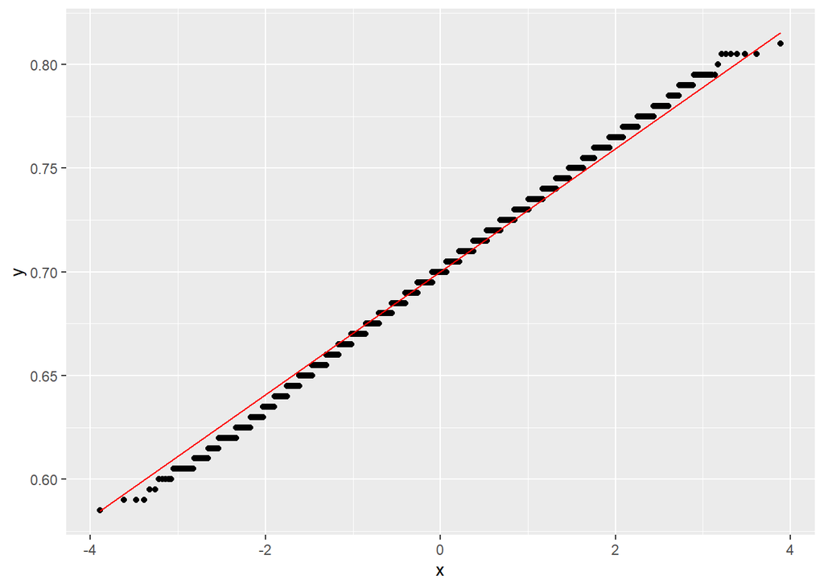

```r
ggplot(prop_soles_tbl, aes(sample = prop_soles)) +
  geom_qq(distribution = stats::qnorm) + geom_qq_line(colour = "red")
```

# Bootstrap

**Ejemplo 1:** Error estándar de una media

Retomaremos el ejemplo de la prueba ENLACE de la tarea anterior.

```r
enlace <- read.csv("../data/enlace_15.csv")
```

Para cada tamaño de muestra n = 10, 100, 1000: i) Selecciona una única muestra y utilizala para estimar la media de las calificaciones de español 3o de primaria ii) Utiliza bootstrap para calcular el error estándar de tu estimador iii) Grafica la distribución bootstrap

### Tamaño de muestra 10

```r
set.seed(8)
n <- 10
muestra_10 <- slice_sample(enlace, n = n)
esp_mean <- mean(muestra_10$esp_3)
esp_mean
```

```
[1] 555.4
```

```r
bootstrap_10 <- map_dbl(1:5000, ~ muestra_10 |>
                  slice_sample(n=n, replace = TRUE) |>
                  summarise(esp_3 = mean(esp_3)) |> pull(esp_3))
```

```r
print(paste0("El error estandar del estimador con muestra de tamaño 10 es: ", round(sd(bootstrap_10), 2)))
```

```
[1] "El error estandar del estimador con muestra de tamaño 10 es: 17.3"
```

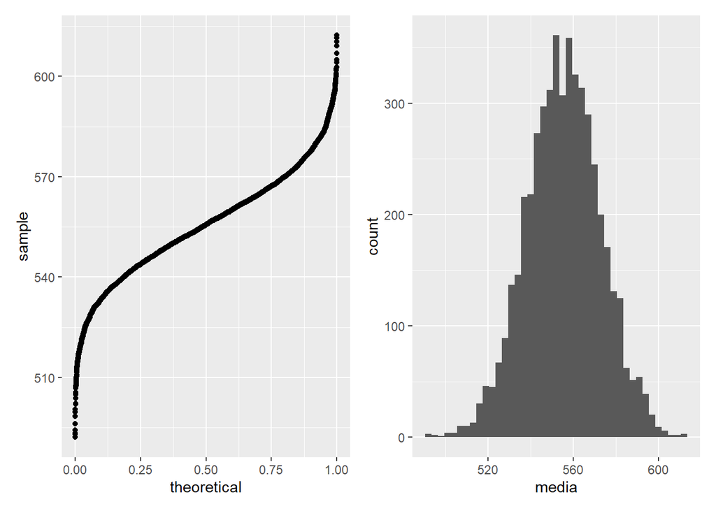

```r
bootstrap <- tibble(media = bootstrap_10)
g_cuantiles <- ggplot(bootstrap, aes(sample = media)) + geom_qq(distribution = stats::qunif)
g_histograma <- ggplot(bootstrap, aes(x = media)) + geom_histogram(binwidth = 3)
g_cuantiles + g_histograma
```

### Tamaño de muestra 100

```r
set.seed(8)
n <- 100
muestra_100 <- slice_sample(enlace, n = n)
esp_mean <- mean(muestra_100$esp_3)
esp_mean
```

```
[1] 554.67
```

```r
bootstrap_100 <- map_dbl(1:5000, ~ muestra_100 |>
                  slice_sample(n=n, replace = TRUE) |>
                  summarise(esp_3 = mean(esp_3)) |> pull(esp_3))
```

```r
print(paste0("El error estandar del estimador con muestra de tamaño 100 es: ",
             round(sd(bootstrap_100), 2)))
```

```
[1] "El error estandar del estimador con muestra de tamaño 100 es: 6.02"
```

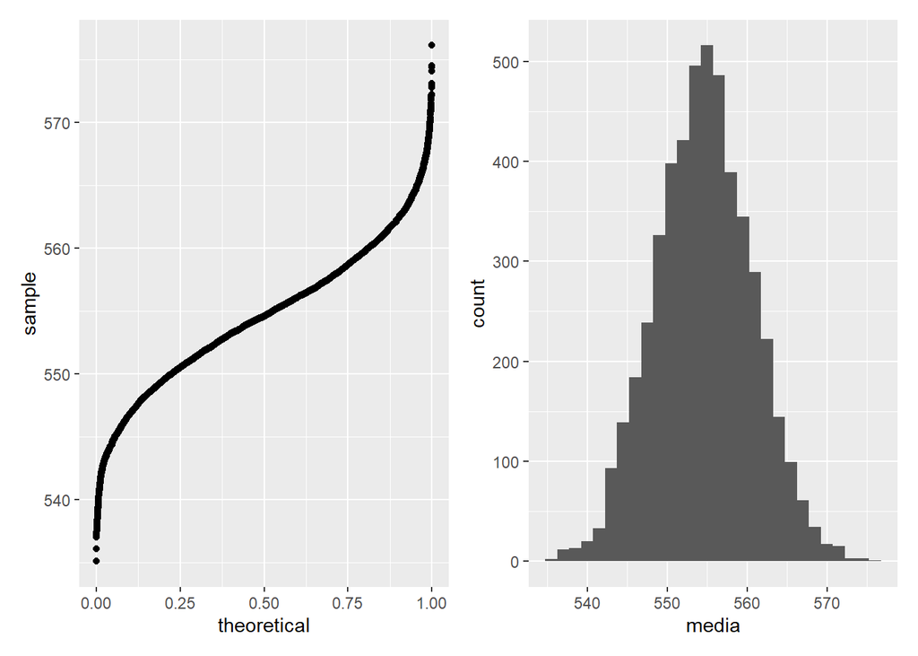

```r
bootstrap <- tibble(media = bootstrap_100)
g_cuantiles <- ggplot(bootstrap, aes(sample = media)) + geom_qq(distribution = stats::qunif)
g_histograma <- ggplot(bootstrap, aes(x = media)) + geom_histogram(binwidth = 1.5)
g_cuantiles + g_histograma
```

### Tamaño de muestra 1000

```r
set.seed(8)
n <- 1000
muestra_1000 <- slice_sample(enlace, n = n)
esp_mean <- mean(muestra_1000$esp_3)
esp_mean
```

```
[1] 552.12
```

```r
bootstrap_1000 <- map_dbl(1:5000, ~ muestra_1000 |>
                  slice_sample(n=n, replace = TRUE) |>
                  summarise(esp_3 = mean(esp_3)) |> pull(esp_3))
```

```r
print(paste0("El error estandar del estimador con muestra de tamaño 1000 es: ",
             round(sd(bootstrap_1000), 2)))
```

```
[1] "El error estandar del estimador con muestra de tamaño 1000 es: 1.82"
```

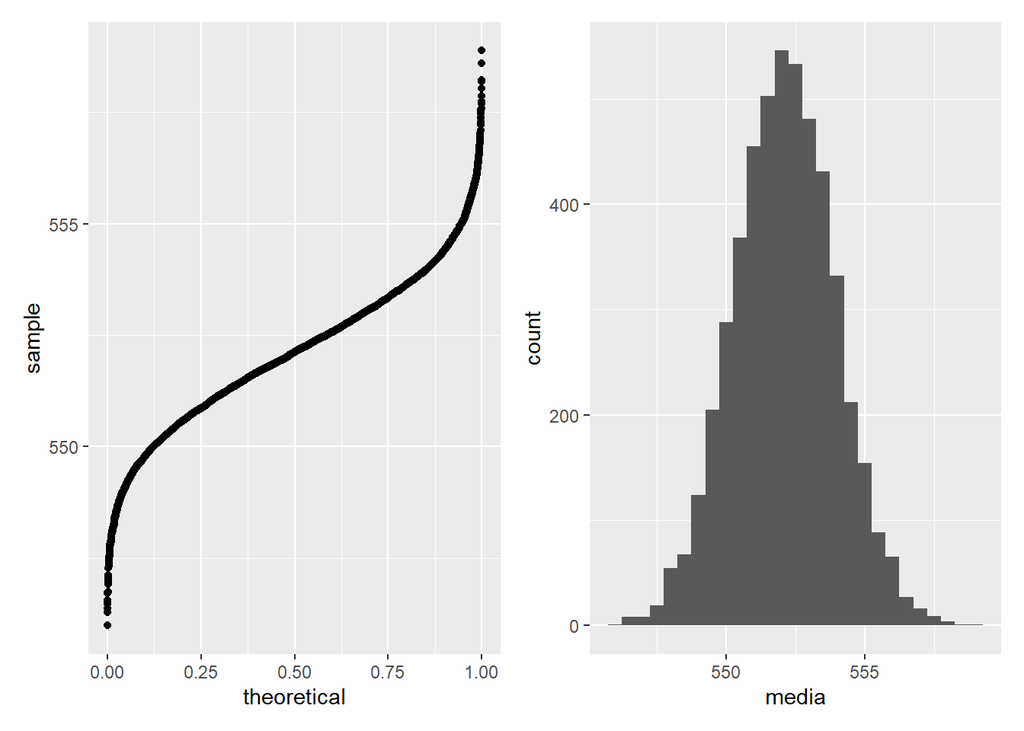

```r
bootstrap <- tibble(media = bootstrap_1000)
g_cuantiles <- ggplot(bootstrap, aes(sample = media)) + geom_qq(distribution = stats::qunif)
g_histograma <- ggplot(bootstrap, aes(x = media)) + geom_histogram(binwidth = 0.5)
g_cuantiles + g_histograma
```

Retoma la muestra de tamaño 100, y calcula la correlación entre las calificaciones de español 3o y 6o de primaria

```r
head(muestra_100)
```

```
     id cve_ent      turno    tipo esp_3 esp_6 n_eval_3 n_eval_6
1 44608      15 VESPERTINO GENERAL   548   473        4        5
2 44052      15   MATUTINO GENERAL   551   554       62       62
3 41852      15   MATUTINO GENERAL   447   519       10        8
4 40341      15 VESPERTINO GENERAL   541   536       46       51
5 43301      15 VESPERTINO GENERAL   548   685       14       26
6 44781      15 VESPERTINO GENERAL   499   582       18       21
```

```r
cor(muestra_100$esp_3, muestra_100$esp_6)
```

```
[1] 0.575242
```

Utiliza bootstrap para calcular el error estandar

```r
corr_100 <- map_dbl(1:5000, ~ muestra_100 |>
                  slice_sample(n=100, replace = TRUE) |>
                  summarise(corr = cor(esp_3, esp_6)) |> pull(corr))
```

```r
print(paste0("El error estandar de la correlación con muestra de tamaño 1000 es: ",
             round(sd(corr_100), 2)))
```

[output not shown]

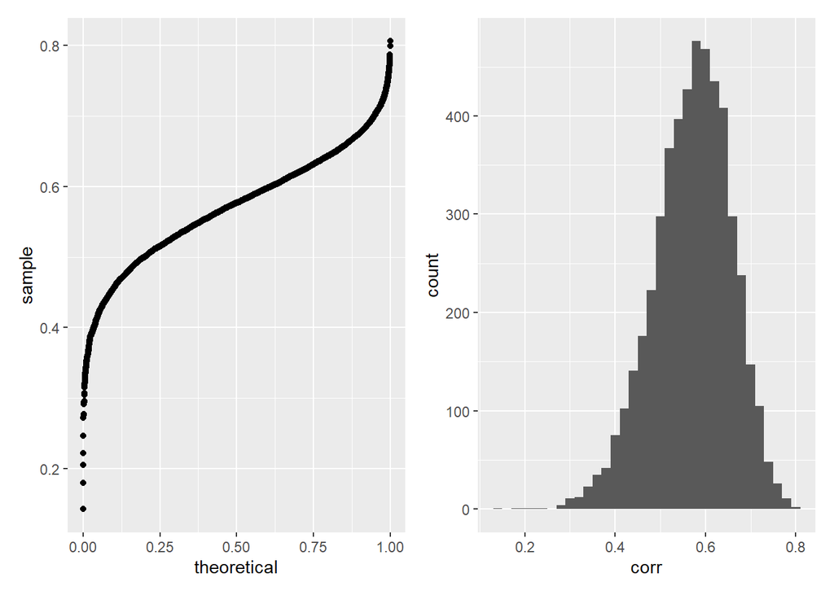

```r
bootstrap <- tibble(corr = corr_100)
g_cuantiles <- ggplot(bootstrap, aes(sample = corr)) + geom_qq(distribution = stats::qunif)
g_histograma <- ggplot(bootstrap, aes(x = corr)) + geom_histogram(binwidth = 0.02)
g_cuantiles + g_histograma
```